# Assignment: Temporal Diversity

Michelle Benavidez; Z620: Quantitative Biodiversity, Indiana University

15 February, 2017

## OVERVIEW

In this Assignment, we extend our understanding of diversity from the spatial dimension to the temporal dimension.

After completing this exercise you will know how to:

1. wrangle a large dataset to visualize and analyze time series data
2. test hypotheses from experiments with temporal data
3. quantify temporal $\beta$-diversity and stability

## Directions:

1. Change “Student Name” on line 3 (above) with your name.
2. Complete as much of the exercise as possible during class; what you do not complete in class will need to be done on your own outside of class.
3. Use the Handout as a guide; it contains a more complete description of data sets along with the proper scripting needed to carry out the exercise.
4. Be sure to **answer the questions** in this exercise document; they also correspond to the Handout. Space for your answer is provided in this document and indicated by the “>” character. If you need a second paragraph be sure to start the first line with “>”.
5. Before you leave the classroom, **push** this file to your GitHub repo.
6. When you are done with the Assignment, **Knit** the text and code into a html file.
7. After Knitting, please submit the completed Assignment by creating a **pull request** via GitHub. Your pull request should include this file *temporal_assignment.Rmd* and the html output of `Knitr` (*temporal_assignment.html*).

## 1) R SETUP

Typically, the first thing you will do in either an R script or an RMarkdown file is setup your environment. This includes things such as setting the working directory and loading any packages that you will need.

In the R code chunk below, provide the code to:

1. clear your R environment,
2. print your current working directory,
3. set your working directory to your “*/Week5-Temporal*” folder, and
4. load any packages you need to complete the assignment.

```r
rm(list=ls())
getwd()
```

```
## [1] "C:/Users/Michelle/GitHub/QB2017_Benavidez/Week5-Temporal"
```

```r
setwd("C:/users/Michelle/GitHub/QB2017_Benavidez/Week5-Temporal/")

require(vegan)
require(tidyr)
require(dplyr)
require(codyn)
```

```r
require(ggplot2)
require(cowplt)
require(MullerPlot)
require(RColorBrewer)
require(reshape2)
require(lubridate)
require(TTR)
require(xtable)
require(multcomp)
require(pander)
require(png)
require(grid)
require(tseries)
require(nlme)
require(forecast)
require(lsmeans)
require("vegan")
require("ade4")
require("BiodiversityR")
require("gplots")
require("viridis")
require("indicspecies")
```

## 2) LOADING DATA

### Load dataset

In the R code chunk below, do the following:

1. load the `portal` dataset from in the “*/Week5/data*” folder, and
2. explore the structure of the dataset.

```r
portal <- read.table("data/combined.csv", sep = ",", header = TRUE)
summary(portal)
```

```
##    record_id         month             day            year
##  Min.   :    1   Min.   : 1.000   Min.   : 1.0   Min.   :1977
##  1st Qu.: 8964   1st Qu.: 4.000   1st Qu.: 9.0   1st Qu.:1984
##  Median :17762   Median : 6.000   Median :16.0   Median :1990
##  Mean   :17804   Mean   : 6.474   Mean   :16.1   Mean   :1990
##  3rd Qu.:26655   3rd Qu.:10.000   3rd Qu.:23.0   3rd Qu.:1997
##  Max.   :35548   Max.   :12.000   Max.   :31.0   Max.   :2002
##
##     plot_id        species_id    sex       hindfoot_length
##  Min.   : 1.00   DM     :10596    : 1748   Min.   : 2.00
##  1st Qu.: 5.00   PP     : 3123   F:15690   1st Qu.:21.00
##  Median :11.00   DO     : 3027   M:17348   Median :32.00
##  Mean   :11.34   PB     : 2891             Mean   :29.29
##  3rd Qu.:17.00   RM     : 2609             3rd Qu.:36.00
##  Max.   :24.00   DS     : 2504             Max.   :70.00
##                  (Other):10036             NA's   :3348
##      weight                   genus               species
##  Min.   :  4.00   Dipodomys      :16167   merriami    :10596
##  1st Qu.: 20.00   Chaetodipus    : 6029   penicillatus: 3123
##  Median : 37.00   Onychomys      : 3267   ordii       : 3027
##  Mean   : 42.67   Reithrodontomys: 2694   baileyi     : 2891
##  3rd Qu.: 48.00   Peromyscus     : 2234   megalotis   : 2609
##  Max.   :280.00   Perognathus    : 1629   spectabilis : 2504
##  NA's   :2503     (Other)        : 2766   (Other)     :10036
##       taxa                           plot_type
##  Bird   :  450   Control                  :15611
##  Rabbit :   75   Long-term Krat Exclosure : 5118
##  Reptile:   14   Rodent Exclosure         : 4233
##  Rodent :34247   Short-term Krat Exclosure: 5906
##                  Spectab exclosure        : 3918
##
##
```

```r
portal2=portal[!(portal$taxa %in% c("Bird","Rabbit","Reptile")),]
```

*Question 1*: Describe some of the attributes of the `portal` dataset.

1. How many plots are in `portal`?
2. How many rodent species are there in the `portal` dataset?

> *Answer 1a*: 24 plots are present  
> *Answer 1b*: After discounting lizards, birds, and rabbits, 29 species of rodents are present - five of these are entered as ‘sp’ (i.e. Dipodomys sp.), so there is a possibility there are more.

## 3) WRANGLING THE PORTAL DATASET

In the R code chunk below, do the following:

1. Create a site-by-species matrix for any year of your choosing.
2. Create a vector of plot_type for sites in the site-by-species matrix.
3. Analyze alpha diversity (e.g., Shannon/Simpson) across the sites for that year.
4. Create a PCoA ordination of your site-by-species matrix.
5. Using the hypothesis testing tools you learned in the beta-diversity module, test the hypothesis that species abundances across sites vary as a factor of treatment type (i.e., plot_type).

```r
portal <- unite(portal, col = date, c(year, month, day), sep = "-", remove = FALSE)
portal <- unite(portal, col = taxon, c(genus, species), sep = "_", remove = FALSE)

time.by.species <- group_by(portal,year,plot_id) %>%
  count(taxon) %>% spread(key=taxon,value=n,fill=0)

dplyr::filter(time.by.species,year==1981, plot_id==6)
```

```
## Source: local data frame [1 x 50]
## Groups: year, plot_id [1]
##
##    year plot_id Ammodramus_savannarum Ammospermophilus_harrisi
##   <int>   <int>                 <dbl>                    <dbl>
## 1  1981       6                     0                        0
## # ... with 46 more variables: Amphispiza_bilineata <dbl>,
## #   Baiomys_taylori <dbl>, Calamospiza_melanocorys <dbl>,
## #   Callipepla_squamata <dbl>, Campylorhynchus_brunneicapillus <dbl>,
## #   Chaetodipus_baileyi <dbl>, Chaetodipus_intermedius <dbl>,
## #   Chaetodipus_penicillatus <dbl>, Chaetodipus_sp. <dbl>,
## #   Cnemidophorus_tigris <dbl>, Cnemidophorus_uniparens <dbl>,
## #   Crotalus_scutalatus <dbl>, Crotalus_viridis <dbl>,
## #   Dipodomys_merriami <dbl>, Dipodomys_ordii <dbl>, Dipodomys_sp. <dbl>,
## #   Dipodomys_spectabilis <dbl>, Lizard_sp. <dbl>, Neotoma_albigula <dbl>,
## #   Onychomys_leucogaster <dbl>, Onychomys_sp. <dbl>,
## #   Onychomys_torridus <dbl>, Perognathus_flavus <dbl>,
## #   Perognathus_hispidus <dbl>, Peromyscus_eremicus <dbl>,
## #   Peromyscus_leucopus <dbl>, Peromyscus_maniculatus <dbl>,
## #   Pipilo_chlorurus <dbl>, Pipilo_fuscus <dbl>, Pipilo_sp. <dbl>,
## #   Pooecetes_gramineus <dbl>, Reithrodontomys_fulvescens <dbl>,
## #   Reithrodontomys_megalotis <dbl>, Reithrodontomys_montanus <dbl>,
## #   Reithrodontomys_sp. <dbl>, Rodent_sp. <dbl>, Sceloporus_clarki <dbl>,
## #   Sceloporus_undulatus <dbl>, Sigmodon_fulviventer <dbl>,
## #   Sigmodon_hispidus <dbl>, Sigmodon_ochrognathus <dbl>,
## #   Sparrow_sp. <dbl>, Spermophilus_spilosoma <dbl>,
## #   Spermophilus_tereticaudus <dbl>, Sylvilagus_audubonii <dbl>,
## #   Zonotrichia_leucophrys <dbl>
```

```r
dplyr::filter(time.by.species,plot_id==6)
```

```
## Source: local data frame [26 x 50]
## Groups: year, plot_id [26]
##
##     year plot_id Ammodramus_savannarum Ammospermophilus_harrisi
##    <int>   <int>                 <dbl>                    <dbl>
## 1   1977       6                     0                        0
## 2   1978       6                     0                        0
## 3   1979       6                     0                        0
## 4   1980       6                     0                        0
## 5   1981       6                     0                        0
## 6   1982       6                     0                        0
## 7   1983       6                     0                        0
## 8   1984       6                     0                        0
## 9   1985       6                     0                        0
## 10  1986       6                     0                        0
## # ... with 16 more rows, and 46 more variables:
## #   Amphispiza_bilineata <dbl>, Baiomys_taylori <dbl>,
## #   Calamospiza_melanocorys <dbl>, Callipepla_squamata <dbl>,
## #   Campylorhynchus_brunneicapillus <dbl>, Chaetodipus_baileyi <dbl>,
## #   Chaetodipus_intermedius <dbl>, Chaetodipus_penicillatus <dbl>,
## #   Chaetodipus_sp. <dbl>, Cnemidophorus_tigris <dbl>,
## #   Cnemidophorus_uniparens <dbl>, Crotalus_scutalatus <dbl>,
## #   Crotalus_viridis <dbl>, Dipodomys_merriami <dbl>,
## #   Dipodomys_ordii <dbl>, Dipodomys_sp. <dbl>,
## #   Dipodomys_spectabilis <dbl>, Lizard_sp. <dbl>, Neotoma_albigula <dbl>,
## #   Onychomys_leucogaster <dbl>, Onychomys_sp. <dbl>,
## #   Onychomys_torridus <dbl>, Perognathus_flavus <dbl>,
## #   Perognathus_hispidus <dbl>, Peromyscus_eremicus <dbl>,
## #   Peromyscus_leucopus <dbl>, Peromyscus_maniculatus <dbl>,
## #   Pipilo_chlorurus <dbl>, Pipilo_fuscus <dbl>, Pipilo_sp. <dbl>,
## #   Pooecetes_gramineus <dbl>, Reithrodontomys_fulvescens <dbl>,
## #   Reithrodontomys_megalotis <dbl>, Reithrodontomys_montanus <dbl>,
## #   Reithrodontomys_sp. <dbl>, Rodent_sp. <dbl>, Sceloporus_clarki <dbl>,
## #   Sceloporus_undulatus <dbl>, Sigmodon_fulviventer <dbl>,
## #   Sigmodon_hispidus <dbl>, Sigmodon_ochrognathus <dbl>,
## #   Sparrow_sp. <dbl>, Spermophilus_spilosoma <dbl>,
## #   Spermophilus_tereticaudus <dbl>, Sylvilagus_audubonii <dbl>,
## #   Zonotrichia_leucophrys <dbl>
```

```r
tbs.1981 <- time.by.species[93:116,]
tbs.forpcoa=tbs.1981[,3:29]

diversity(tbs.1981,"simp")
```

```
##  [1] 0.075804885 0.085387908 0.026680132 0.064891372 0.078779145
##  [6] 0.075659866 0.008015427 0.069461919 0.087951923 0.023763036
## [11] 0.090615190 0.113074514 0.098270513 0.098201176 0.046662477
## [16] 0.018845000 0.089932403 0.084542908 0.047558058 0.089832262
## [21] 0.040018256 0.081012731 0.032364314 0.090665212
```

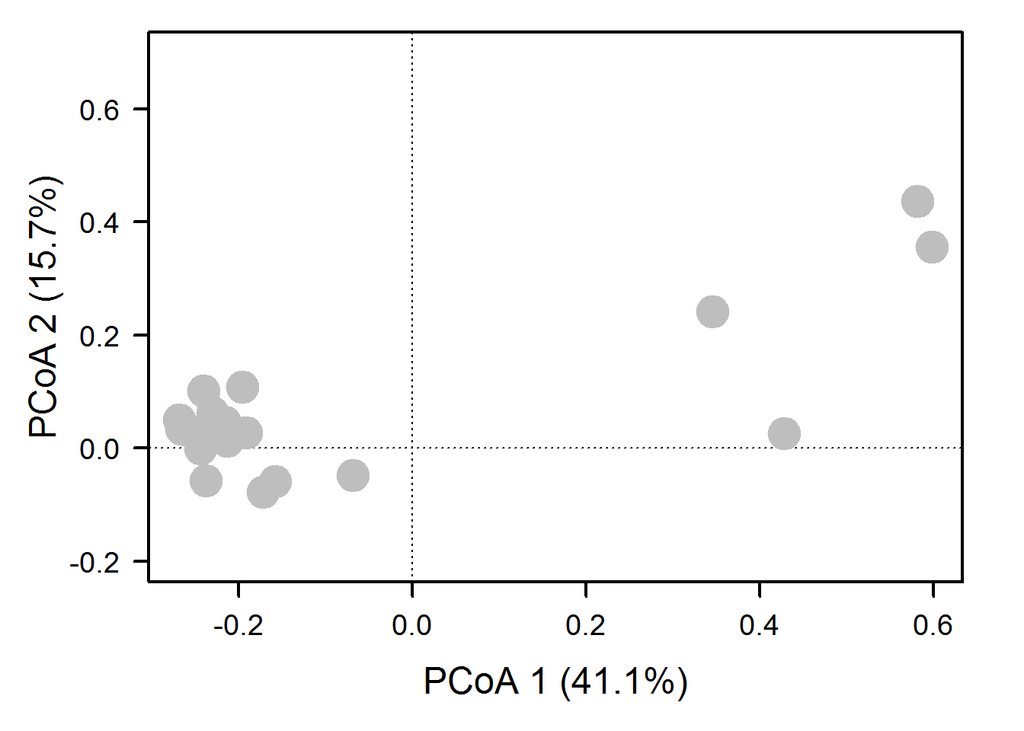

```r
tbs1981.db=vegdist(tbs.forpcoa,method="bray")

rodent.pcoa=cmdscale(tbs1981.db,eig=T, k=3)
explainvar1=round(rodent.pcoa$eig[1] / sum(rodent.pcoa$eig), 3) * 100
explainvar2=round(rodent.pcoa$eig[2] / sum(rodent.pcoa$eig), 3) * 100
explainvar3=round(rodent.pcoa$eig[3] / sum(rodent.pcoa$eig), 3) * 100
sum.eig=sum(explainvar1,explainvar2,explainvar3)

par(mar = c(5, 5, 1, 2) + 0.1)
plot(rodent.pcoa$points[ ,1], rodent.pcoa$points[ ,2], ylim = c(-0.2, 0.7),
    xlab = paste("PCoA 1 (", explainvar1, "%)", sep = ""),
    ylab = paste("PCoA 2 (", explainvar2, "%)", sep = ""),
    pch = 16, cex = 2.0, type = "n", cex.lab = 1.5, cex.axis = 1.2, axes = FALSE)
axis(side = 1, labels = T, lwd.ticks = 2, cex.axis = 1.2, las = 1)
axis(side = 2, labels = T, lwd.ticks = 2, cex.axis = 1.2, las = 1)
abline(h = 0, v = 0, lty = 3)
box(lwd = 2)
points(rodent.pcoa$points[ ,1], rodent.pcoa$points[ ,2],
       pch = 19, cex = 3, bg = "gray", col = "gray")
text(rodent.pcoa$points[ ,1], rodent.pcoa$points[ ,2],
     labels = row.names(rodent.pcoa$points))
```

```r
rodentREL=tbs.forpcoa

  for(i in 1:nrow(tbs.forpcoa)){
    rodentREL[i, ] = tbs.forpcoa[i, ] / sum(tbs.forpcoa[i, ])
  }

plot=c(1:24)
tbs.stat=tbs.1981[2:31]
adonis(tbs.stat~plot,method="bray",permtations=999)
```

```
##
## Call:
## adonis(formula = tbs.stat ~ plot, method = "bray", permtations = 999)
##
## Permutation: free
## Number of permutations: 999
##
## Terms added sequentially (first to last)
##
##           Df SumsOfSqs MeanSqs F.Model      R2 Pr(>F)
## plot       1    0.7414 0.74137   4.709 0.17631  0.011 *
## Residuals 22    3.4636 0.15744         0.82369
## Total     23    4.2050                 1.00000
## ---
## Signif. codes:  0 '***' 0.001 '**' 0.01 '*' 0.05 '.' 0.1 ' ' 1
```

*Question 2*: Describe how different biodiversity estimates vary among sites.

1. Does diversity vary among sites? Does this correspond to treatment type?
2. Is treatment type a significant predictor of site dissimilarity?

## 4) TIME SERIES ANALYSIS

In the R code chunk below, do the following:

1. Create a time-by-species matrix that includes year, month, and plot_id for a site other than plot_id 2.
2. Examine per-hectare rodent abundance using simple moving average smoothing.
3. Test whether your data meets the assumption of stationarity.
4. If it does not meet this asumption, explore wasy to make your data stationary.
5. Examine and plot time lags using the partial autocorrelation function (PACF) and autocorrelation function (ACR).
6. Use the tools outlined in the Handout to create an ARMA model.

```r
time.by.spec.2 <- filter(portal, taxa=="Rodent") %>%
  group_by(year,month, plot_id) %>%
  count(taxon)

time.by.spec.2$season <- NA
time.by.spec.2$season <- time.by.spec.2$month %in% c(6:10)

time.by.spec.2$season <- ifelse(time.by.spec.2$season == TRUE, "rain", "norain")

group_by(time.by.spec.2, year, season)
```

```
## Source: local data frame [16,391 x 6]
## Groups: year, season [52]
##
##     year month plot_id                    taxon     n season
##    <int> <int>   <int>                    <chr> <int>  <chr>
## 1   1977     7       1       Dipodomys_merriami     2   rain
## 2   1977     7       1       Perognathus_flavus     1   rain
## 3   1977     7       2 Chaetodipus_penicillatus     1   rain
## 4   1977     7       2       Dipodomys_merriami     1   rain
## 5   1977     7       2         Neotoma_albigula     1   rain
## 6   1977     7       2      Peromyscus_eremicus     1   rain
## 7   1977     7       3       Dipodomys_merriami     2   rain
## 8   1977     7       3    Dipodomys_spectabilis     1   rain
## 9   1977     7       3         Neotoma_albigula     1   rain
## 10  1977     7       4       Dipodomys_merriami     1   rain
## # ... with 16,381 more rows
```

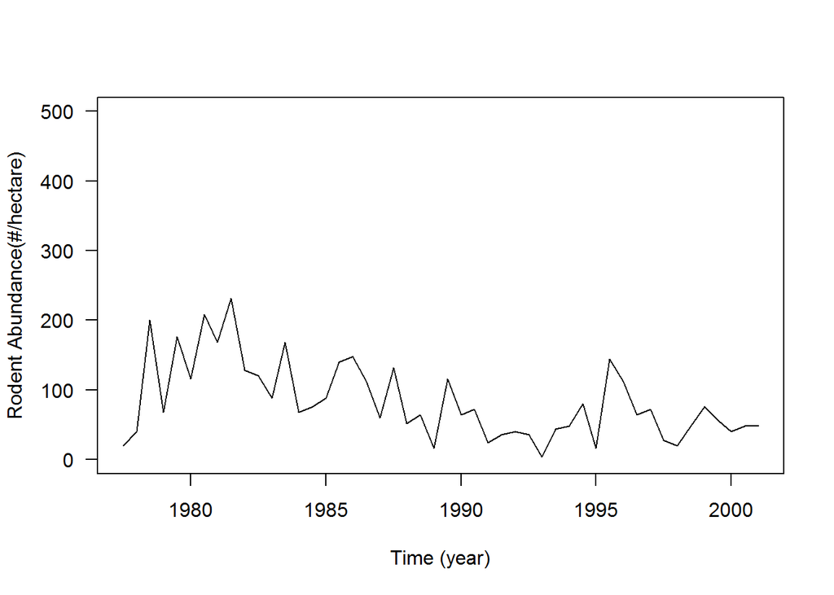

```r
abund <- filter(time.by.spec.2, plot_id == 24) %>%
  group_by(year, season) %>%
  count(wt = n)

abund$nn <- abund$nn * 4

abund.ts <- ts(abund$nn, frequency = 2, start = c(1977, 2))

plot.ts(abund.ts, type = "l", ylab = "Rodent Abundance(#/hectare)",
        xlab = "Time (year)", las = 1, ylim = c(0, 500))
```

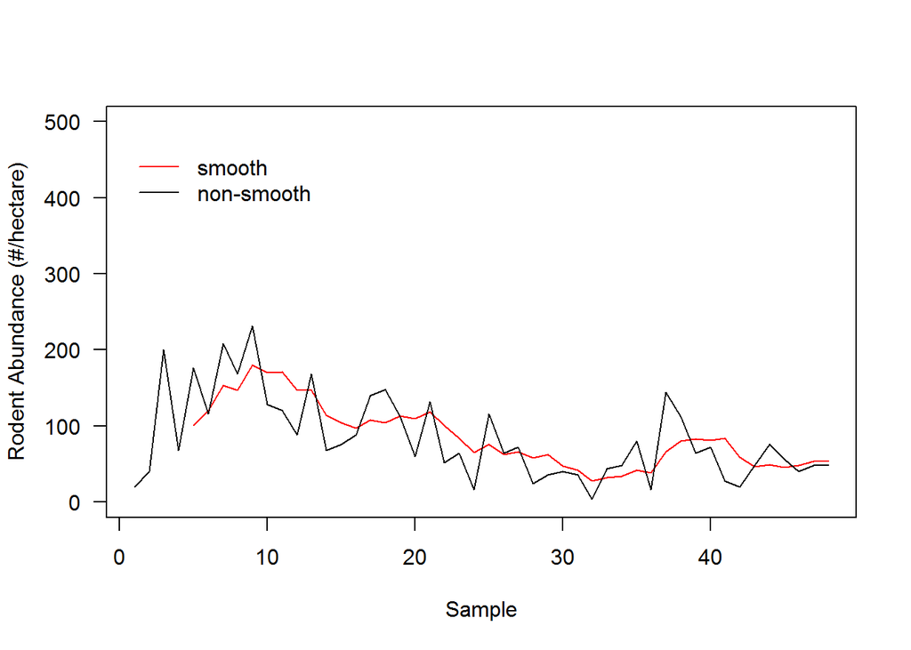

```r
#smoothing
abund.sm <- SMA(abund$nn, n = 5)

plot(abund.sm, type = "l", col = "red", ylab = "Rodent Abundance (#/hectare)",
     xlab = "Sample", las = 1, ylim = c(0, 500))

lines(abund$nn, col = "black")

legend(0, 475, col = c("red", "black"), lty = c(1,1),
       c("smooth", "non-smooth"), bty = "n", cex = 1)
```

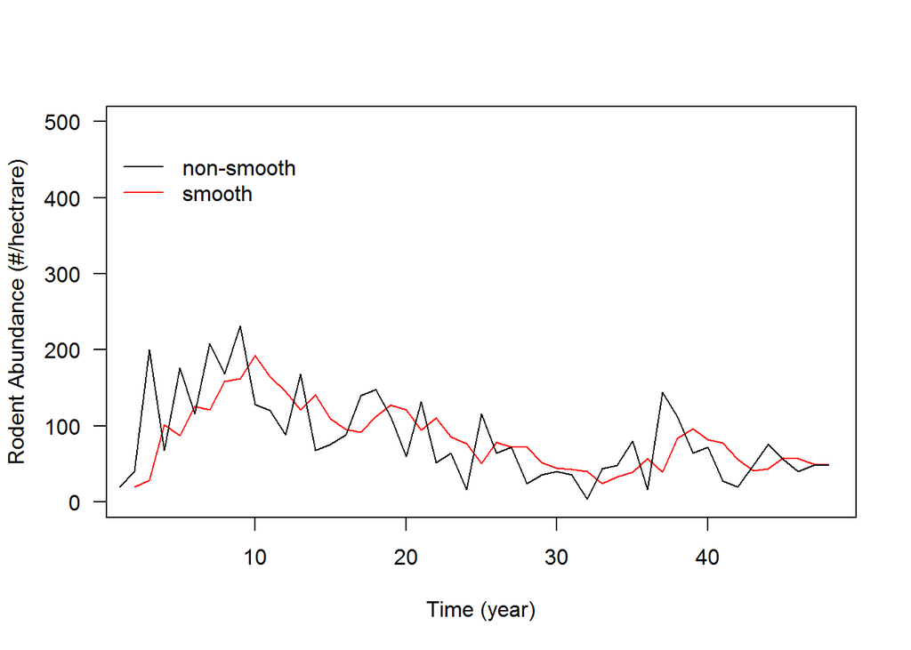

```r
#exponential smoothing
abund.hw <- HoltWinters(abund$nn, beta = FALSE, gamma = FALSE)

plot(abund.hw, xlab = "Time (year)", ylim = c(0, 500),
     ylab = "Rodent Abundance (#/hectrare)", las = 1, main = NA)

legend(0, 475, col = c("black", "red"), lty = c(1,1),
       c("non-smooth", "smooth"), bty = "n", cex = 1)
```

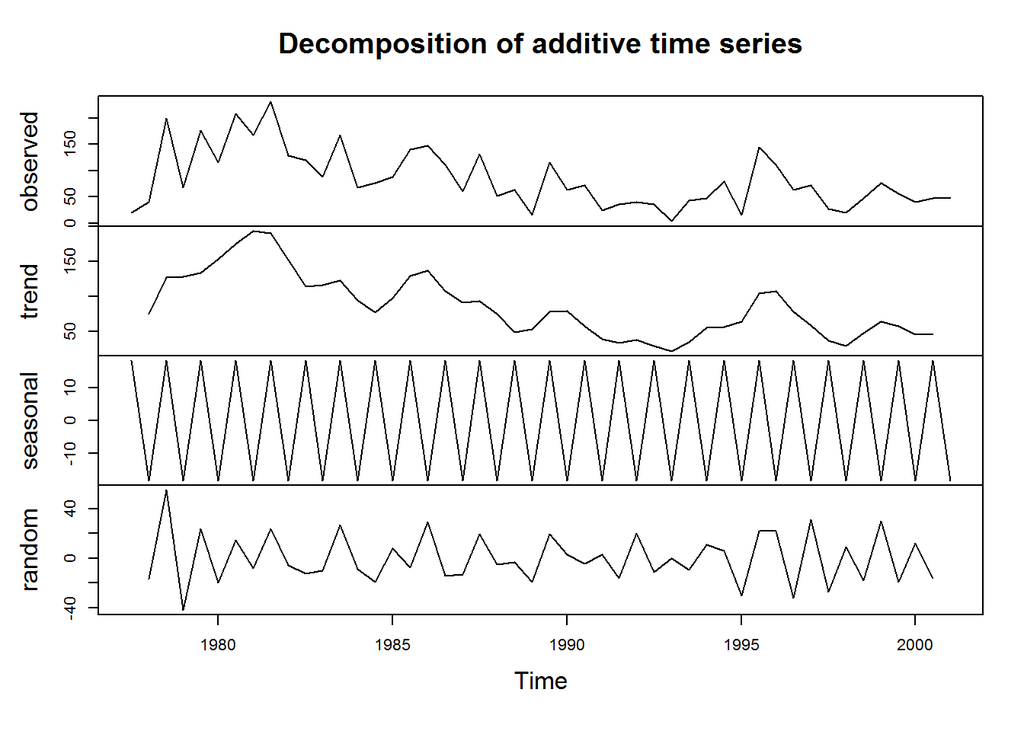

```r
#decomposition
abund.comp <- decompose(abund.ts)
plot(abund.comp)
```

```r
abund.adj <- abund.ts - abund.comp$seasonal

#stationarity

adf.raw <- adf.test(abund.ts, alternative = "stationary")
adf.raw$p.value
```

```
## [1] 0.2547674
```

```r
abund.ts.diff <- diff(abund.ts)
adf.diff <- adf.test(abund.ts.diff, alternative = "stationary")
adf.diff$p.value
```

```
## [1] 0.0109537
```

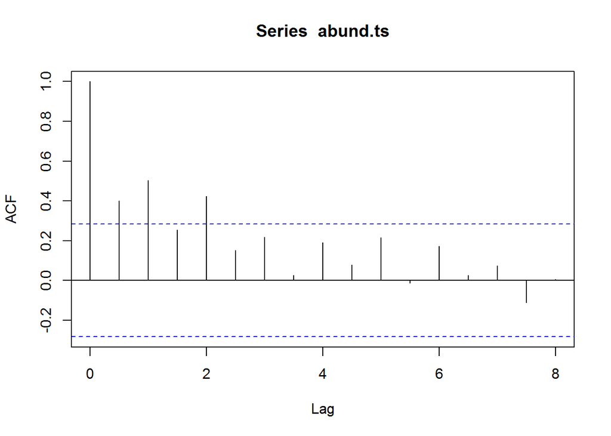

```r
#pacf and acf
acf(abund.ts)
```

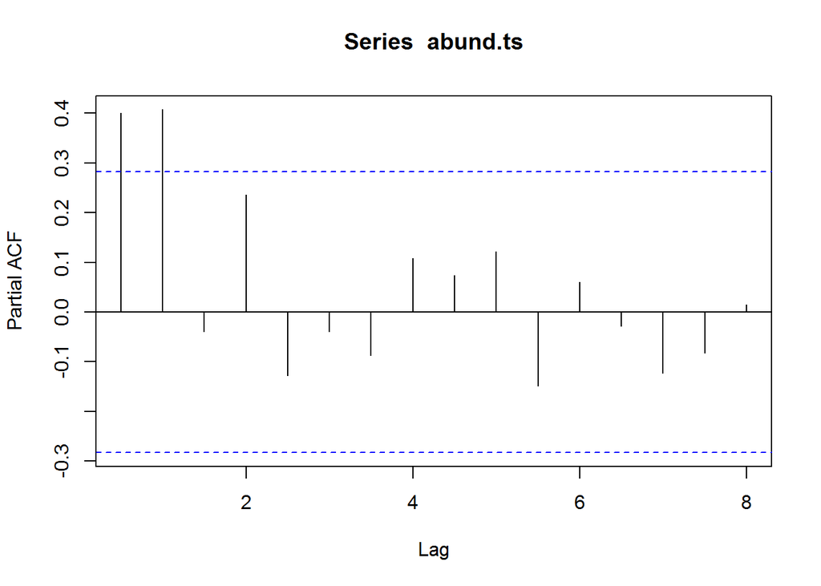

```r
pacf(abund.ts)
```

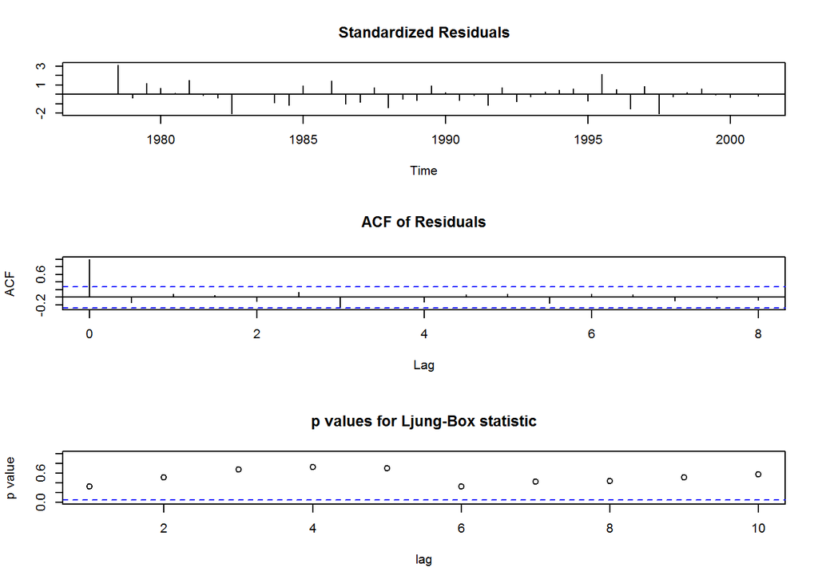

```r
#arma
abund.arm <- auto.arima(abund.ts)
abund.arm <- arima((abund.ts), c(0, 0, 1), seasonal = list(order = c(2, 1, 0),
                                                           period = 2), include.mean =
                     TRUE)


tsdiag(abund.arm)
```

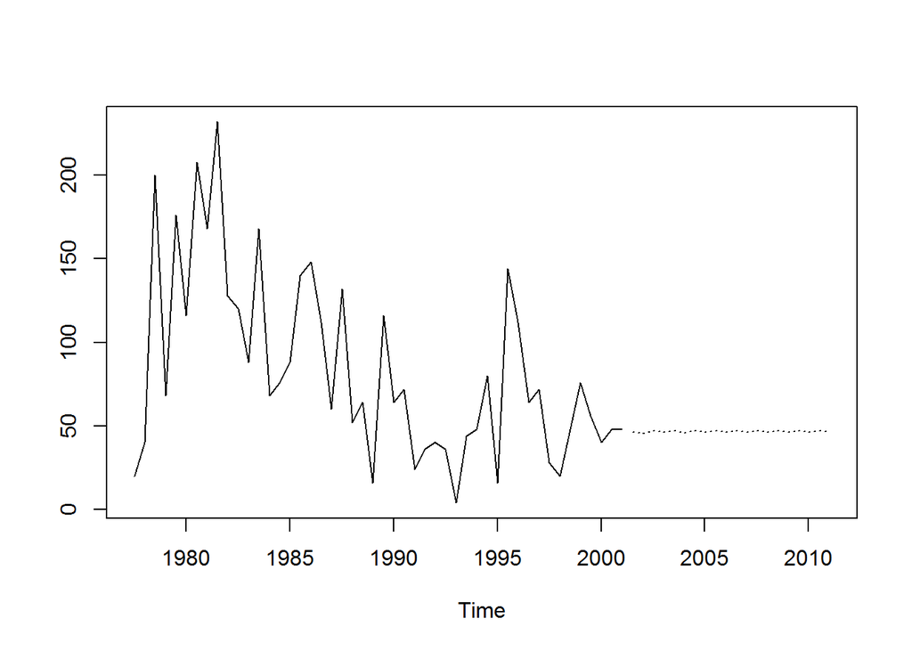

```r
pred.arm <- predict(abund.arm, n.ahead = 20)
ts.plot(abund.ts, pred.arm$pred, lty = c(1,3))
```

*Question 3*: Describe the results from your time series analysis.

1. Does your data meet the assumption of stationarity? If not, what does this violation imply?
2. What does the ACF function do and how does it relate to the ARMA model? How does this differ from PACF?
3. What results can you conclude from your full ARMA model along with other methods outlined in the time series setcion of the Handout?

> *Answer 3a*: The data did not meet the assumption of similarity based on the Dicky-Fuller test (p = 0.25). Hoever, after differencing the time series, it did meet the assumption of stationarity (p < 0.05). *Answer 3b*: ACF is the autocorreltion function and it lets the researcher determines correltion that may be inconspicuously located time series intervals. This relates to the ARMA models because it can help paramatize the model so it can generate more informative forcasts. Unlike AFC which looks for lagtime correlations arcoss the data, PACF looks for correlation lagtimes between two time intervals. Essentially, the AFC measures autocorrelation in the ‘MA’ (moving average) portion of the ARMA models and PACF measure autocorrelation in the ‘AF’ (autoreggresive) portion of the model. *Answer 3c*: Based on the model conclusions, rodent abundance increased after the plot was established then steadily decresaed and will likely stablize at a relatively low density through the future.

## 5) REPEATED MEASURES ANALYSIS OF VARIANCE (RM-ANOVA)

In the R code chunk below, do the following:

1. Create an appropriate data frame for RM-ANOVA (e.g., yearly species abundance values within plots).
2. Calculate the inverse of Simpson’s diversity for each year, and plot it as a function of year for the Control and Rodent Exclosure plots.
3. Perform an RM-ANOVA and construct a F-test using the AR(1), compound symmetery, and unstructured covariance structures.

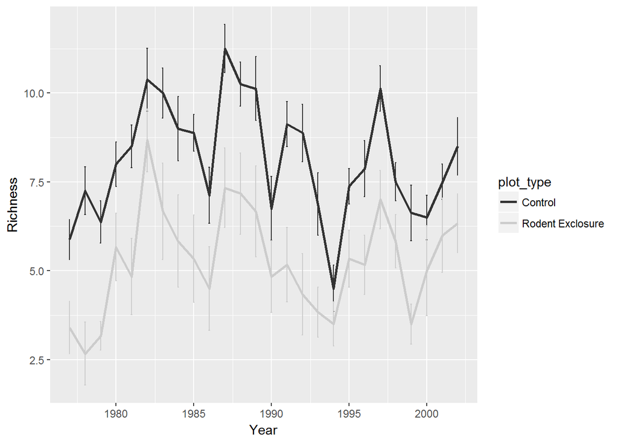

```r
##Wrangling data
# time-by-species matrix
time.by.species <- group_by(portal, year, plot_id,
                            plot_type) %>% count(taxon) %>% spread(key = taxon, value = n,
                                                                   fill = 0)

# observed richness from time-by-species matrix
richness <- as.data.frame(rowSums(time.by.species[,-c(1:3)] > 0))

# data frame with experimental design and richness data
rich.all <- data.frame(time.by.species[,1:3,], richness)

# Rename column
names(rich.all)[4] <- "richness"


# Pull out two of the five Portal treatments
rich.treat <- rich.all[which(rich.all$plot_type ==
                               "Control" | rich.all$plot_type == "Rodent Exclosure"), ]

##Plotting data
rich.treat.plot <- group_by(rich.treat, plot_type, year) %>%
  summarise(
    mean = mean(richness),
    sd = sd(richness),
    n = n(),
    sem = sd/sqrt(n))

rich.plot <- ggplot(rich.treat.plot, aes(x = year, y = mean, color = plot_type)) +
  geom_line(size = 1, show.legend = T) +
  geom_errorbar(aes(ymin = mean - sem, ymax = mean + sem), width = .1) +
  xlim(1977, 2002) +
  xlab("Year") +
  ylab("Richness")+
  scale_color_grey()

plot(rich.plot)
```

```r
#autoregressive
rich.rm <- lme(richness ~ plot_type * year, random = ~ 1 | plot_id,
               correlation = corAR1(form = ~ 1 | plot_id),
               data = rich.treat)
summary(rich.rm)
```

```
## Linear mixed-effects model fit by REML
##  Data: rich.treat
##        AIC      BIC    logLik
##   1590.462 1617.567 -788.2309
##
## Random effects:
##  Formula: ~1 | plot_id
##         (Intercept) Residual
## StdDev:    1.296979 2.246238
##
## Correlation Structure: AR(1)
##  Formula: ~1 | plot_id
##  Parameter estimate(s):
##     Phi
## 0.37097
## Fixed effects: richness ~ plot_type * year
##                                    Value Std.Error  DF    t-value p-value
## (Intercept)                     28.62737  57.07705 343  0.5015565  0.6163
## plot_typeRodent Exclosure      -62.03957  89.14103  12 -0.6959710  0.4997
## year                            -0.01033   0.02869 343 -0.3600129  0.7191
## plot_typeRodent Exclosure:year   0.02980   0.04480 343  0.6652702  0.5063
##  Correlation:
##                                (Intr) plt_RE year
## plot_typeRodent Exclosure      -0.64
## year                           -1.00   0.64
## plot_typeRodent Exclosure:year  0.64  -1.00  -0.64
##
## Standardized Within-Group Residuals:
##         Min          Q1         Med          Q3         Max
## -2.98978687 -0.69549540 -0.07250359  0.68791058  2.73090608
##
## Number of Observations: 359
## Number of Groups: 14
```

```r
anova(rich.rm)
```

```
##                numDF denDF  F-value p-value
## (Intercept)        1   343 319.5050  <.0001
## plot_type          1    12  12.2775  0.0044
## year               1   343   0.0074  0.9316
## plot_type:year     1   343   0.4426  0.5063
```

```r
set.caption("RMANOVA for Portal")
pander(anova(rich.rm))
```

RMANOVA for Portal

|  | numDF | denDF | F-value | p-value |
| --- | --- | --- | --- | --- |
| **(Intercept)** | 1 | 343 | 319.5 | 0 |
| **plot_type** | 1 | 12 | 12.28 | 0.00435 |
| **year** | 1 | 343 | 0.007381 | 0.9316 |
| **plot_type:year** | 1 | 343 | 0.4426 | 0.5063 |

```r
lsmeans(rich.rm, ~plot_type)
```

```
## NOTE: Results may be misleading due to involvement in interactions
```

```
##  plot_type          lsmean        SE df lower.CL upper.CL
##  Control          8.078695 0.5107372 13 6.975315 9.182076
##  Rodent Exclosure 5.338471 0.5916197 12 4.049442 6.627499
##
## Confidence level used: 0.95
```

```r
#unstructured
#rich.rmuns <- lme(richness ~ plot_type * year, random = ~ plot_type * year | plot_id, data = rich.treat,correlation = corSymm(form = ~ 1 | plot_id), control = lmeControl(opt='optim'))


#compound symmetry
rich.rmcom <- lme(richness ~ plot_type * year, random = ~ 1 | plot_id,
               correlation = corCompSymm(form = ~ 1 | plot_id),
               data = rich.treat)
summary(rich.rmcom)
```

```
## Linear mixed-effects model fit by REML
##  Data: rich.treat
##        AIC      BIC    logLik
##   1634.628 1661.733 -810.3142
##
## Random effects:
##  Formula: ~1 | plot_id
##         (Intercept) Residual
## StdDev:    1.395556 2.185797
##
## Correlation Structure: Compound symmetry
##  Formula: ~1 | plot_id
##  Parameter estimate(s):
##          Rho
## 6.672013e-18
## Fixed effects: richness ~ plot_type * year
##                                    Value Std.Error  DF   t-value p-value
## (Intercept)                     61.25855  40.20654 343  1.523597  0.1285
## plot_typeRodent Exclosure      -66.04270  62.95273  12 -1.049084  0.3148
## year                            -0.02671   0.02021 343 -1.321744  0.1871
## plot_typeRodent Exclosure:year   0.03181   0.03164 343  1.005341  0.3154
##  Correlation:
##                                (Intr) plt_RE year
## plot_typeRodent Exclosure      -0.639
## year                           -1.000  0.639
## plot_typeRodent Exclosure:year  0.639 -1.000 -0.639
##
## Standardized Within-Group Residuals:
##        Min         Q1        Med         Q3        Max
## -3.0806434 -0.6993469 -0.0728110  0.6795500  2.7655354
##
## Number of Observations: 359
## Number of Groups: 14
```

```r
anova(rich.rmcom)
```

```
##                numDF denDF   F-value p-value
## (Intercept)        1   343 315.82853  <.0001
## plot_type          1    12  12.25170  0.0044
## year               1   343   0.78014  0.3777
## plot_type:year     1   343   1.01071  0.3154
```

```r
set.caption("RMANOVA for Portal")
pander(anova(rich.rmcom))
```

RMANOVA for Portal

|  | numDF | denDF | F-value | p-value |
| --- | --- | --- | --- | --- |
| **(Intercept)** | 1 | 343 | 315.8 | 0 |
| **plot_type** | 1 | 12 | 12.25 | 0.00438 |
| **year** | 1 | 343 | 0.7801 | 0.3777 |
| **plot_type:year** | 1 | 343 | 1.011 | 0.3154 |

```r
lsmeans(rich.rmcom, ~plot_type)
```

```
## NOTE: Results may be misleading due to involvement in interactions
```

```
##  plot_type          lsmean        SE df lower.CL upper.CL
##  Control          8.117551 0.5161597 13 7.002456 9.232646
##  Rodent Exclosure 5.357391 0.5968970 12 4.056865 6.657918
##
## Confidence level used: 0.95
```

*Question 4*: Describe the results from your RM-ANOVA.

1. In your own words describe what a RM-ANOVA test is doing
2. Is there a noticeable trend in the inverse of Simpson’s diversity over time?
3. What does the result of your F-test tell you?
4. Of the three RM-ANOVA models with different covariance structures, which one is best? How does this affect the interpretation of your data?

> *Answer 4a*: It is testing the effect of plot_type, year, and the interaction between plot_type and year on the response variable (rodent richness). It is basically a regular ANOVA, but for nonindependent groups. In this example, we are testing for differences in intercept (time) since we don’t have an a priori reason to test intercept-slope model.  
> *Answer 4b*: Based on eyeballing the plot, it seems as if there might be a slight increase of richness over time and the two plot types seems to follow the same general trends (however this may be due to environmental changes). *Answer 4c*: Plot_type has a significant effect on rodent richness (F = 12.28, df = 1/12, p < 0.01). Neither year (F = 0.01, df = 1/343, p = 0.93) nor the interaction between year and plot_type (F = 0.45, df = 1/343, p = 0.51) have a significant effect on rodent richness. Therefore, there is a significant difference in richness over time when you compare full rodent exclosure from a plot and full rodent access to a plot, and this is most fully explained by the plot_type treatment. In general, based on the F values treatment means only considerably differ between plot types. *Answer 4d*: The autoregressive model appeared to work the best. This would say that the time intercept is a good measure of diversity change over time.

## 6) TEMPORAL BETA DIVERSITY

### Turnover

In the R code chunk below, do the following:

1. Calculate species abundances for each taxonomic group (the `taxa` column).
2. Calculate total turnover and turnover due to the gain/loss of species for each group.
3. Visualize turnover within each group

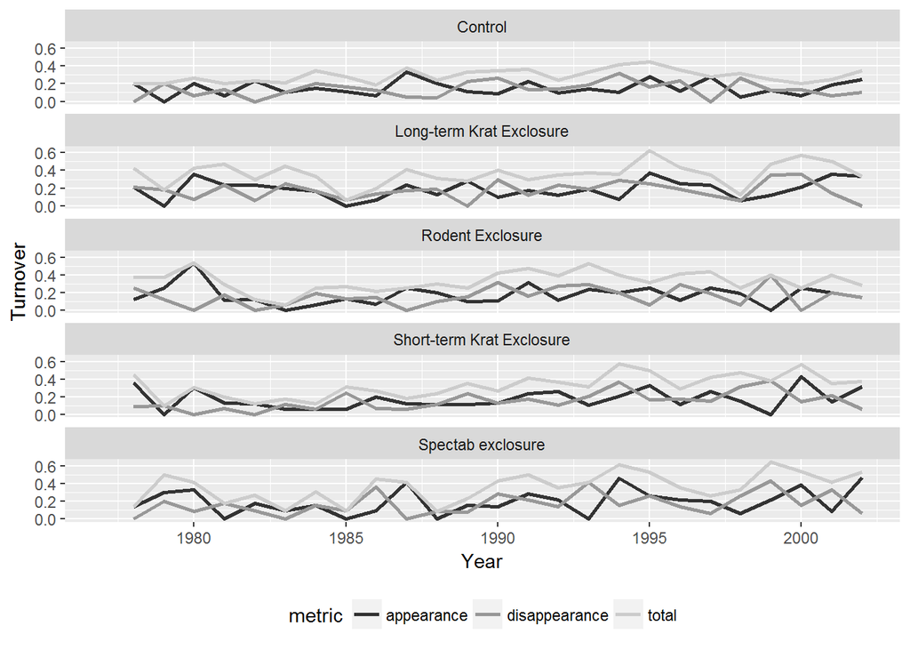

```r
portal.species.abunds <- group_by(portal, year, plot_type) %>% count(taxon)

portal.total <- turnover(df = portal.species.abunds,
                         time.var = "year",
                         species.var = "taxon",
                         abundance.var = "n",
                         replicate.var = "plot_type",
                         metric = "total")

portal.appearance <- turnover(df = portal.species.abunds,
                              time.var = "year",
                              species.var = "taxon",
                              abundance.var = "n",
                              replicate.var = "plot_type",
                              metric = "appearance")

portal.disappearance <- turnover(df = portal.species.abunds,
                                 time.var = "year",
                                 species.var = "taxon",
                                 abundance.var = "n",
                                 replicate.var = "plot_type",
                                 metric = "disappearance")

portal.turnover <- full_join(portal.total, portal.disappearance) %>%
  full_join(portal.appearance)
portal.turnover <- gather(portal.turnover, key = metric, value = turnover,
                          total, appearance, disappearance)

turn.plot <- ggplot(
  portal.turnover, aes(x = year, y = turnover, color = metric)) +
  geom_line(size = 1, show.legend = T) +
  facet_wrap(~plot_type, ncol = 1) +
  xlim(1977, 2002) +
  xlab("Year") +
  ylab("Turnover") +
  theme(legend.position = "bottom") +
  scale_color_grey()

plot(turn.plot)
```

*Question 5*:

1. How does temporal turnover relate to spatial turnover?
2. Which taxonomic group appears to be the most variable? Which group appears to be the least variable?

> *Answer 5a*: Time and space are inherently linked in that changes in space occurr over time. Therefore, it is imporant to consider temporal and spatial turnover when examining temporal data to better understand how and why your reponse variable is changing. *Answer 5a*: The taxonomic group that excludes Dypodomys spectabilis is the most variable. The control treatment is the least variable.

### Mean Rank Shift

In the code chunk below, do the following:

1. Choose two plot_types or two plot_ids and compare the mean rank shift (MRS) between them.
2. Plot MRS for each through time.

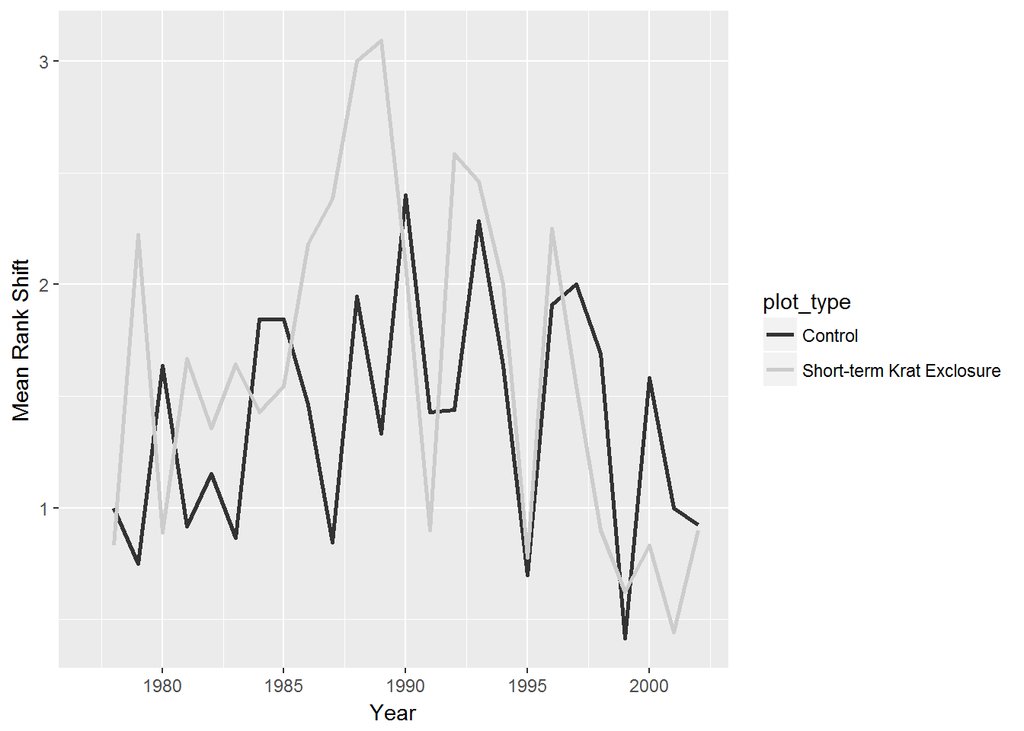

```r
portal.abunds.cont.rodent <- filter(portal.species.abunds,
                                    plot_type == "Control" | plot_type == "Short-term Krat Exclosure")

portal.rankshift <- rank_shift(
  df = as.data.frame(portal.abunds.cont.rodent),
  time.var = "year",
  species.var = "taxon",
  abundance.var = "n",
  replicate.var = "plot_type")

portal.rankshift$year <- as.numeric(substr(portal.rankshift$year_pair, 6, 9))

rankshift.plot <- ggplot(portal.rankshift, aes(x = year, y = MRS, color = plot_type)) +
  geom_line(size = 1) +
  xlim(1977, 2002) +
  xlab("Year") +
  ylab("Mean Rank Shift") +
  scale_color_grey()

plot(rankshift.plot)
```

```r
group_by(portal.rankshift, plot_type) %>%
  summarise(
    mean = mean(MRS),
    cv = sd(MRS)/mean)
```

```
## # A tibble: 2 × 3
##                   plot_type     mean        cv
##                       <chr>    <dbl>     <dbl>
## 1                   Control 1.400675 0.3759483
## 2 Short-term Krat Exclosure 1.622171 0.4751513
```

*Question 6*:

1. What does a change in the rank shift tell you about the community?
2. Interpret the analysis and figure you just made.

### Rate Change Interval

In the R code chunk below, do the following:

1. Calculate the rate change interval using the Hellinger distance.
2. Plot the results.

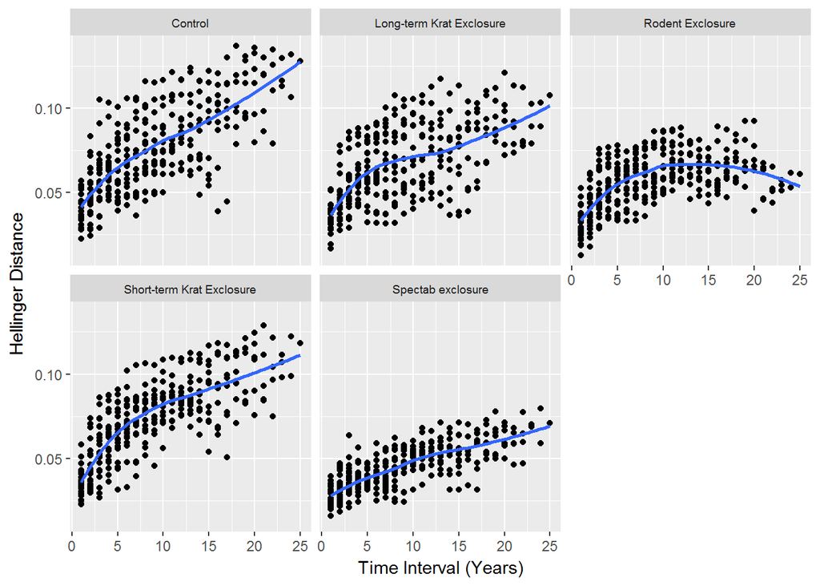

```r
portal.species.abunds$tot.abund <- rep(sum(portal.species.abunds$n),
                                       length(portal.species.abunds$n))

portal.hellinger.transf <- portal.species.abunds %>%
  mutate(hellinger.transf = sqrt(n / tot.abund))

portal.change.int <- rate_change_interval(portal.hellinger.transf,
                                          time.var = "year",
                                          species.var = "taxon",
                                          abundance.var = "hellinger.transf",
                                          replicate.var = "plot_type")

rate.plot <- ggplot(portal.change.int, aes(interval, distance)) +
  geom_point() +
  facet_wrap(~plot_type) +
  theme(strip.text.x = element_text(size = 7)) +
  stat_smooth(method = "loess", se = F, size = 1) +
  ylab("Hellinger Distance") +
  xlab("Time Interval (Years)")

rate.plot
```

*Question 7*:

1. What does it mean to calculate a distance metric across varying time intervals?
2. Interpret the overall results. Develop a hypothesis based on the different responses of each treatment.

> *Answer 7a*: We are calculating how probable similarity changes over time. In this we can develop hypotheses concerning community divergence and which can ultimately inform ecological manamgement and conservation pratices. *Answer 7b*: Hellinger distances steadily increased through time for all treatments except for the rodent enclosure, where all rodents were exluded from entry. Since the rodent enclosure expludes all rodents while the other treatments include at least on species of rodent, then dispersal capabilites great influence community divergence over time.

## 7) STABILITY

In the R code chunk below, do the following:

1. Using total abundance as your focal variable, calculate stability (i.e., 1/CV) and synchrony for each plot type.
2. Test for a biodiversity-stability relationship by regressing community stability on mean richness.
3. Test for a biodiversity-stability relationship by regressing community stability on mean inverse Simpson’s diversity.

```r
#community stability
portal.stab <- community_stability(df = as.data.frame(portal.species.abunds),
                                   time.var = "year",
                                   abundance.var = "n",
                                   replicate.var = "plot_type")

pander(portal.stab)
```

| plot_type | stability |
| --- | --- |
| Control | 3.044 |
| Long-term Krat Exclosure | 1.865 |
| Rodent Exclosure | 1.864 |
| Short-term Krat Exclosure | 2.462 |
| Spectab exclosure | 2.911 |

```r
#species synchrony
portal.loreau <- synchrony(df = as.data.frame(portal.species.abunds),
                           time.var = "year",
                           species.var = "taxon",
                           abundance.var = "n",
                           replicate.var = "plot_type",
                           metric = "Loreau")

names(portal.loreau)[2] <- "loreau"

portal.gross <- synchrony(df = as.data.frame(portal.species.abunds),
                          time.var = "year",
                          species.var = "taxon",
                          abundance.var = "n",
                          replicate.var = "plot_type",
                          metric = "Gross")

names(portal.gross)[2] <- "gross"

pander(full_join(portal.loreau, portal.gross))
```

| plot_type | loreau | gross |
| --- | --- | --- |
| Control | 0.1869 | 0.1263 |
| Long-term Krat Exclosure | 0.1578 | 0.07418 |
| Rodent Exclosure | 0.187 | 0.1423 |
| Short-term Krat Exclosure | 0.08773 | 0.001546 |
| Spectab exclosure | 0.1542 | 0.1393 |

```r
#variance ratio
portal.vr <- variance_ratio(df = as.data.frame(portal.species.abunds),
                            time.var = "year", species.var = "taxon",
                            abundance.var = "n", replicate.var = "plot_type",
                            bootnumber = 1000, average.replicates = T,
                            level = 0.95)
pander(portal.vr)
```

| lowerCI | upperCI | nullmean | VR |
| --- | --- | --- | --- |
| 0.6832 | 1.39 | 1.005 | 1.325 |

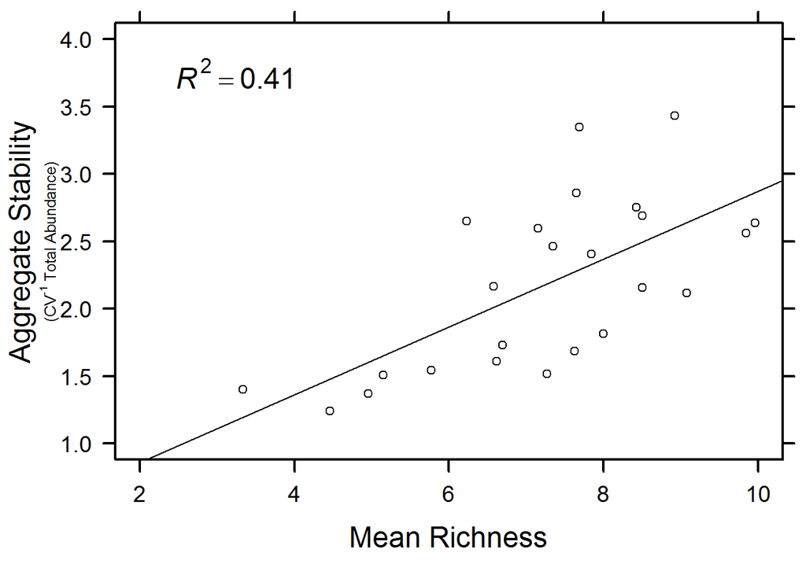

```r
#biodiversity-stability
portal.mean.rich.plot <- rich.all %>%
  group_by(plot_id) %>%
  summarise(mean.rich = mean(richness))

portal.plot.abunds <- as.data.frame(
  group_by(portal, year, plot_id) %>% count(taxon))

portal.stab.plot <- community_stability(df = portal.plot.abunds,
                                        time.var = "year",
                                        abundance.var = "n",
                                        replicate.var = "plot_id")

portal.div.stab <- portal.mean.rich.plot %>%
  inner_join(portal.stab.plot)
par(mar = c(5,5,1,1))

plot(portal.div.stab$stability ~ portal.div.stab$mean.rich,
     xlab = "", ylab = "", yaxt = "n", xaxt = "n",
     xlim = c(2,10), ylim = c(1,4))
axis(side = 1, cex.axis = 1.2, lwd.ticks = 2, las = 1)
axis(side = 2, cex.axis = 1.2, lwd.ticks = 2, las = 1)
axis(side = 3, lwd.ticks = 2, las = 1, labels = F)
axis(side = 4, lwd.ticks = 2, las = 1, labels = F)
box(lwd = 2)
mtext("Mean Richness", side = 1, line = 3, cex = 1.5)
mtext("Aggregate Stability", side = 2, line = 3.5, cex = 1.5)
mtext(expression(paste("(CV"^"-1"," Total Abundance)")),
      side = 2, line = 2.25, cex = .8)

div.stab.lm <- lm(portal.div.stab$stability ~ portal.div.stab$mean.rich)

abline(div.stab.lm)

r2 <- bquote(italic(R)^2 == .(format(
  summary(div.stab.lm)$adj.r.square, digits = 3)))
text(3.25,3.75, cex = 1.5, labels = r2)
```

*Question 8*:

1. Which plot type has the highest stability in total abundance? How is stability of total abundance measured with the function you learned? How does this measure of stability relate to the coefficient of variation?
2. In your own words, describe the concept of synchrony
3. Interpret the results from the biodiversity-stability relationships you analyzed.

## SYNTHESIS

Compare and contrast the core concepts from temporal and spatial diversity (e.g., autocorrelation, scale, variability, etc.). Identify a few of the major challenges associated with studying biodiversity through time and across space.

> *Answer*: Autocorrelation between temporal and spatial scales are similar in that they are looking for internal correlative patters, however they are caluculated differently. Spatially is essentially less complex because it is looking at a single point in time and does not have to account for lag time effects as needs to be considered with temporal autocorrelation. Scale is also similar between evaluating spatial and temporal data - however, they are referring to two particularly different things. In spatial analyses scale is referring to the size of the study area - for example, how many square kilometers are needed to caluculate diversity of grasses in central park? In temoral analyses, lenth of time is the scale - using the same example, how many years should diversity be measured to understand succession of grasses since the contruciton of Central Park? Variability, like scale, is a similar concept within spatial and temporal diversity but it is estimated in different ways depending on your study. In spatial ecology variabiliy is measuring a single instance while in temporal ecology isis measuring change in variability over time. That said, you do need to look at variability of the spaital scope of your temporal analyses in order to look at how that variability changed over time. Stability is a concept that is only useful for temporal/spatiotemporal studies because it innately implies change over time. However, turnover can work for both space and time independently - you can look at turnover through years or between sites at a given point in time.

> Studying biodiversity through space and time can be challenging, especially if you want to generate future forcasts. This is primarily true because it is very difficult to account for all of the ever-changing variables that might be influencing biodiversity in any given area. This becomes exceptionally complicated if you consider humana activiy. For exmaple, if you are attempting to forcast how diversity and age class of trees in a park will look in the future, how do you account for changing managment practices of the city in which the park is located? Can you adequately predict if funding will even allow for management? Furthermore, identifying the appropriate scope of a project is difficult as well - how much/little space and time is necessary to adequatly measure the phenomonon you are attempting to describe? Is four years enough time to measure succession rates after a forest fire? 10 years? How much of the affected area is enough to sample in order to get a representative subset of the entire ecoregion?